# Session 3: Plotting with ggplot2 + other useful packages

1 June 2022

# 1) Plotting with ggplot2

## Data

We will use the same data that was used in Session 2 (on Tuesday).

```r
library(readr)

# If chunks run seperately, ../data/gapminder-FiveYearData.csv
gapminder <- read_csv(file = "data/gapminder-FiveYearData.csv")

head(gapminder)
```

```
## # A tibble: 6 × 6
##   country      year      pop continent lifeExp gdpPercap
##   <chr>       <dbl>    <dbl> <chr>       <dbl>     <dbl>
## 1 Afghanistan  1952  8425333 Asia         28.8      779.
## 2 Afghanistan  1957  9240934 Asia         30.3      821.
## 3 Afghanistan  1962 10267083 Asia         32.0      853.
## 4 Afghanistan  1967 11537966 Asia         34.0      836.
## 5 Afghanistan  1972 13079460 Asia         36.1      740.
## 6 Afghanistan  1977 14880372 Asia         38.4      786.
```

## Basic ggplot call

Plot gdpPercap vs lifeExp.

Basic components of ggplots:

1. `ggplot()`,
2. layers: `geom_point`, `geom_line`, `geom_boxplot`, `geom_hex`, … more geometric objects, known as [geoms](http://ggplot2.tidyverse.org/reference/).
3. add layers: `+`

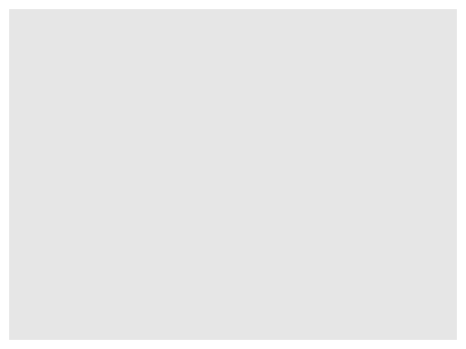

```r
library(ggplot2)

# draw on a whiteboard
ggplot()
```

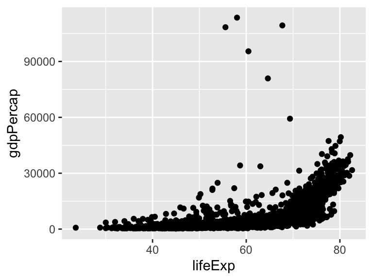

```r
# add a layer: points
#  1) data
#  2) variables (aes)
#  3) color, size, shape, fill

ggplot() +
  geom_point(data = gapminder, aes(x = lifeExp, y = gdpPercap))
```

Aesthetics: **locally** vs **globally**:

Dots with gdpPercap above 60000 are highlighted

```r
ggplot() +
  geom_point(data = gapminder,
             aes(x = lifeExp, y = gdpPercap)) +
  geom_point(data = gapminder %>%
               filter(gdpPercap >60000),
             aes(x = lifeExp, y = gdpPercap), color = "red")
```

The data, x, y used in two layers are the same, so we could define them globally to simplify the code.

```r
ggplot(data = gapminder, aes(x = lifeExp, y = gdpPercap)) +
  geom_point() +
  geom_point(data = . %>%
               filter(gdpPercap >60000), color = "red")
```

Let’s change the colors, size, shape and the transparency of the points:

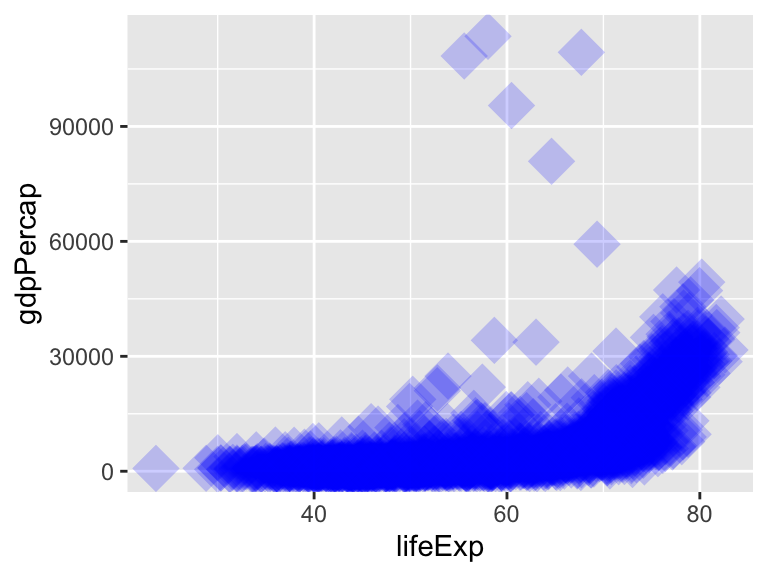

```r
ggplot() +
  geom_point(data = gapminder,
             aes(x = lifeExp, y = gdpPercap),
             color = "blue", size = 8, shape = 18, alpha = 0.2)
```

Let’s color the points by the continent

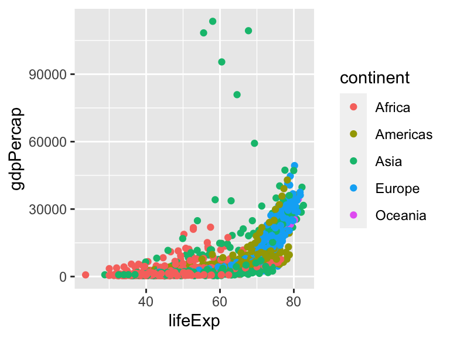

```r
#Use default colors
ggplot() +
  geom_point(data = gapminder,
             aes(x = lifeExp, y = gdpPercap, color = continent))
```

```r
#Use custom colors
ggplot() +
  geom_point(data = gapminder,
             aes(x = lifeExp, y = gdpPercap, color = continent)) +
  scale_color_manual(values = c("orange", "blue", "green", "red", "pink"))
```

There are other `scale_` options to change the shape, size, linetype, etc. Go to [this link](http://ggplot2.tidyverse.org/reference/scale_manual.html) for ways to implement them.

Here we change the shape for each continent:

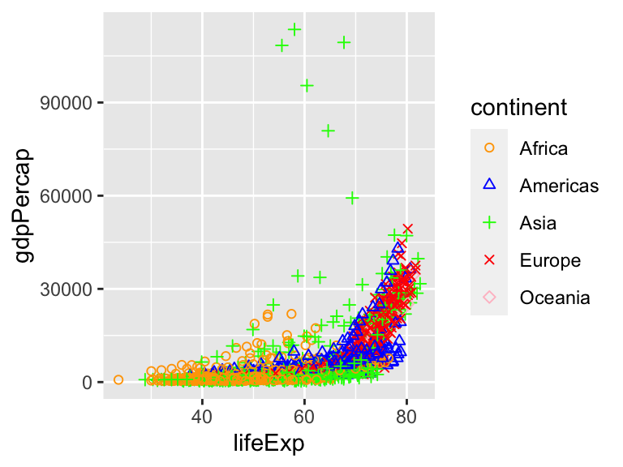

```r
ggplot() +
  geom_point(data = gapminder,
             aes(x = lifeExp, y = gdpPercap, color = continent, shape = continent)) +
  scale_color_manual(values = c("orange", "blue", "green", "red", "pink")) +
  scale_shape_manual(values = 1:5)
```

If we have a continuous variable like `year`, we should use a continuous gradient of colors and here, we’ve also modified the scale of the y axis to spread out the points more:

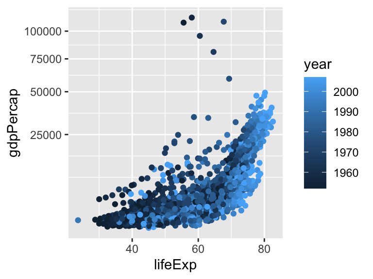

```r
ggplot() +
  geom_point(data = gapminder,
             aes(x = lifeExp, y = gdpPercap, color = year)) +
  scale_y_sqrt()
```

We can change the color gradient by using for example, the rainbow palette `rainbow()`:

```r
ggplot(data = gapminder, aes(x = lifeExp, y = gdpPercap, color = year)) +
  geom_point() +
  scale_color_gradientn(colours = rainbow(5))

  #We can also pick colours individually
  #scale_color_gradientn(colours = c("orange", "blue", "green", "red", "pink"))
```

We use the `colorRampPalette` function to generate a continuous gradient from any set of colors

```r
library(RColorBrewer)

colors2 <- colorRampPalette(c("red", 'orange', "green", 'darkgreen'))(10)
colors2 #is a vector with all the color names

ggplot(data = gapminder) +
  geom_point(aes(x = lifeExp, y = gdpPercap, color = year)) +
  scale_colour_gradientn(colours = colors2)
```

The viridis package offers continuous color gradients designed in a way to ensure readability for readers with common forms of color vision deficiency. The package comes with convenience functions that can be directly used with the ggplot syntax. The different scales can be found [here](https://cran.r-project.org/web/packages/viridis/vignettes/intro-to-viridis.html).

```r
library(viridis)

ggplot(data = gapminder) +
  geom_point(aes(x = lifeExp, y = gdpPercap, color = year)) +
  scale_color_viridis_b()
```

Also commonly used is the `brewer.pal` function to choose a predefined set of colors. The RColorBrewer package offers both discrete and continuous color palettes. Take a look at them [here](https://www.r-bloggers.com/2015/04/create-colorful-graphs-in-r-with-rcolorbrewer-and-plotly/)

```r
colors2 <- colorRampPalette(brewer.pal(n = 9, name = "YlGnBu"))(20)

ggplot(data = gapminder) +
  geom_point(aes(x = lifeExp, y = gdpPercap, color = year)) +
  scale_colour_gradientn(colours = colors2)


# or use scale_colour_distiller
ggplot(data = gapminder) +
  geom_point(aes(x = lifeExp, y = gdpPercap, color = year)) +
  scale_colour_distiller(palette = "YlGnBu", direction = 1)
```

More gradient scales: http://ggplot2.tidyverse.org/reference/scale_gradient.html

## Axis

The first two approaches (`scale_x_continuous(limits = c())`, `xlim()`) remove the data points before plotting.

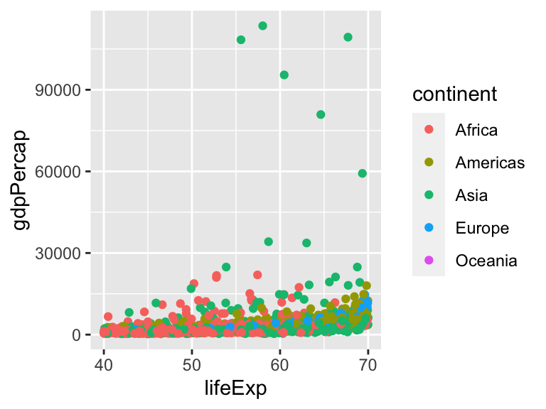

```r
ggplot(data = gapminder) +
  geom_point(aes(x = lifeExp, y = gdpPercap, color = continent)) +
  xlim(40, 70)
```

```r
# scale_x_continuous(limits = c(40, 70))
# coord_cartesian(xlim = c(40, 70))
```

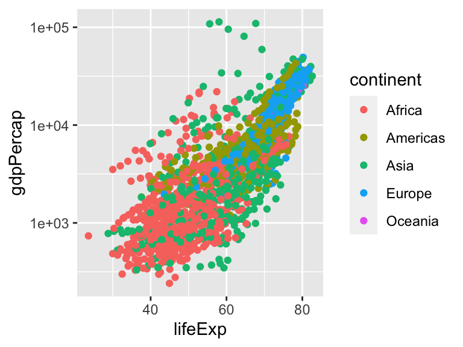

```r
ggplot(data = gapminder) +
  geom_point(aes(x = lifeExp, y = gdpPercap, color = continent)) +
  scale_y_log10()
```

## Theme

The black and white theme `theme_bw()`:

```r
ggplot(data = gapminder) +
  geom_point(aes(x = lifeExp, y = gdpPercap, color = continent)) +
  theme_bw()
```

Modify components of a theme [see more here](http://ggplot2.tidyverse.org/reference/theme.html). See also the hrbrthemes package for additional themes.

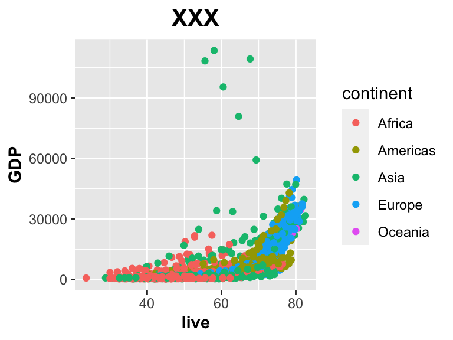

```r
ggplot(data = gapminder) +
  geom_point(aes(x = lifeExp, y = gdpPercap, color = continent)) +
  labs(x = "live", y = "GDP", title = "XXX") +
  theme(axis.title = element_text(face = "bold"),
        plot.title = element_text(face = "bold", size = 15, hjust = 0.5))
```

## Faceting

Let’s stratify the plot by continent with `facet_wrap()`:

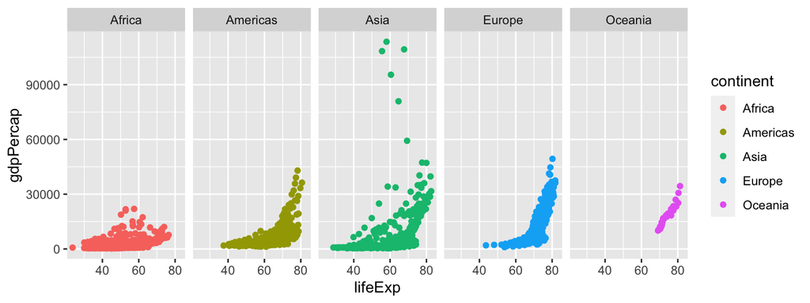

```r
ggplot(data = gapminder) +
  geom_point(aes(x = lifeExp, y = gdpPercap, color = continent)) +
  facet_wrap(~ continent, nrow =1)
```

See also `facet_grid()` here

## Other geoms

See http://ggplot2.tidyverse.org/reference/

### Histogram

Rather for continuous data.

Histogram of lifeExp:

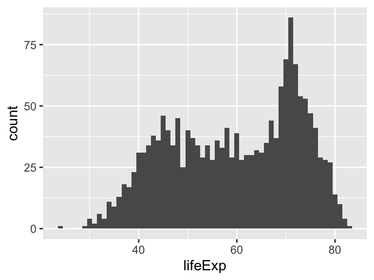

```r
ggplot(data = gapminder, aes(x = lifeExp)) +
  geom_histogram(binwidth = 1)
```

Colored by continent:

```r
ggplot(data = gapminder, aes(x = lifeExp, fill = continent)) + #use fill instead of color
  geom_histogram(binwidth = 1)
```

### Density

Distribution of lifeExp represented with density:

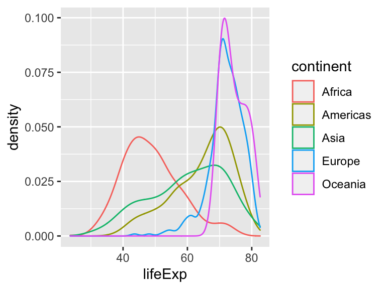

```r
ggplot(data = gapminder, aes(x = lifeExp, color = continent)) +
  geom_density()
```

Plot a line per country and color by continent:

```r
ggplot(data = gapminder, aes(x = lifeExp, color = continent, group = country)) +
  geom_density()
```

### Barplot

Rather for discrete data.

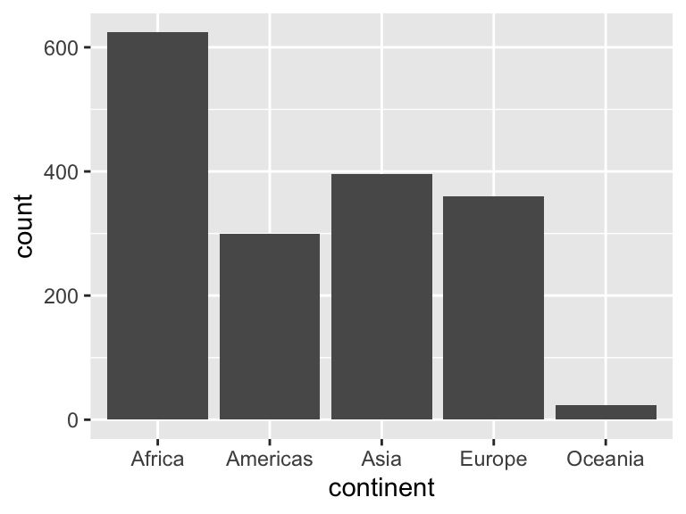

```r
ggplot(data = gapminder, aes(x = continent)) +
  geom_bar()
```

### Violin plot + boxplot + jitter

We can plot multiple layers in one figure.

Let’s represent the distributions of gdpPercap for each continent:

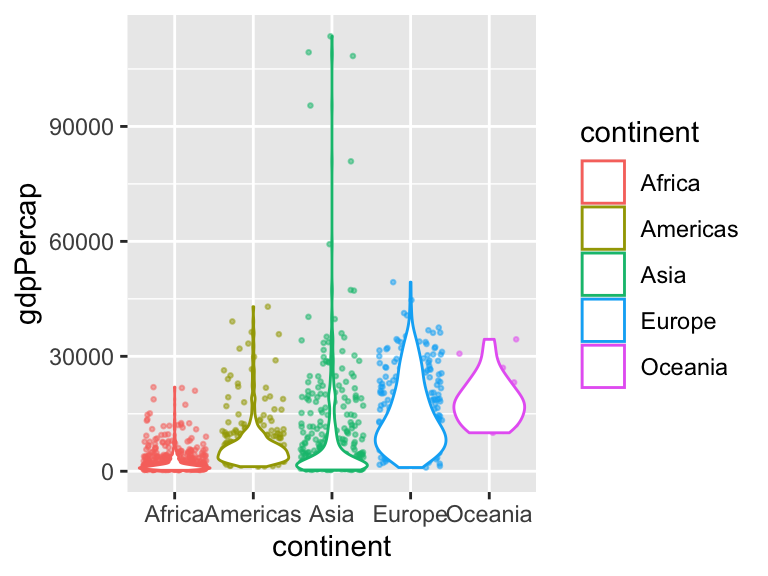

```r
ggplot(data = gapminder, aes(x = continent, y = gdpPercap, color = continent)) +
  geom_jitter(size = 0.5, alpha = 0.5) +
  #geom_boxplot(outlier.color = NA) +
  geom_violin(scale = "width")
```

## Saving figures

Using `pdf()`, `png()`, `bmp()`, `tiff()`, or `jpeg()` and `dev.off()`:

```r
pdf("hist1.pdf")
ggplot(data = gapminder, aes(x = gdpPercap)) +
  geom_histogram(bins = 50)
dev.off()
```

Using `ggsave()`:

```r
ggplot(data = gapminder, aes(x = gdpPercap)) +
  geom_histogram(bins = 50)

ggsave("hist3.pdf")
#ggsave("hist3.png")
```

Note that you can change the extension file in `ggsave` for any other image format (e.g. jpg, png, tiff), just by changing the file name.

## Multipanel figures with cowplot

See [Introduction to cowplot](https://cran.r-project.org/web/packages/cowplot/vignettes/introduction.html).

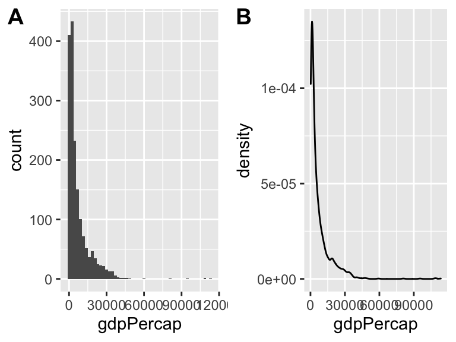

```r
library(cowplot)

ggp1 <- ggplot(data = gapminder, aes(x = gdpPercap)) +
  geom_histogram(bins = 50)

ggp2 <- ggplot(data = gapminder, aes(x = gdpPercap)) +
  geom_density()

plot_grid(ggp1, ggp2, labels = c("A", "B"))
```

As an alternative the ggarrange function of the [ggpubr package](https://rpkgs.datanovia.com/ggpubr/) also provides an interface for multipanel figures and shared legends (ggpubr is actually a wrapper around `cowplot`).

```r
library(ggpubr)
```

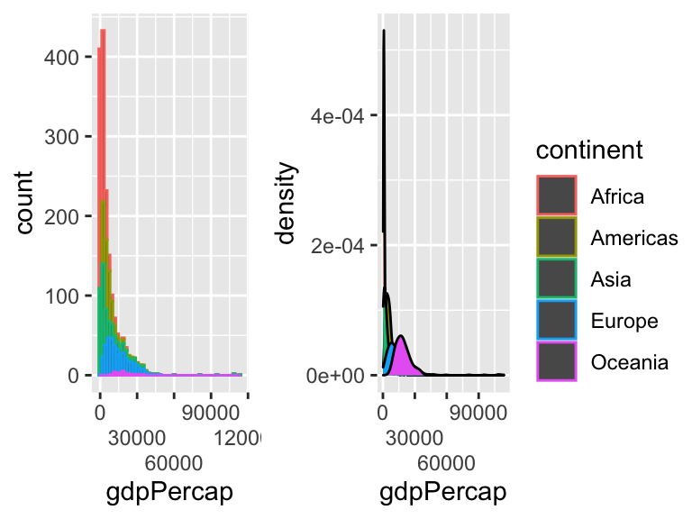

```r
ggp1 <- ggplot(data = gapminder, aes(x = gdpPercap, color=continent)) +
  scale_x_continuous(guide=guide_axis(n.dodge=3)) + # dodge can be used to avoid overlapping axis text
  geom_histogram(bins = 50)

ggp2 <- ggplot(data = gapminder, aes(x = gdpPercap, fill=continent)) +
  scale_x_continuous(guide=guide_axis(n.dodge=3)) +
  geom_density()

ggarrange(ggp1, ggp2, ncol=2, common.legend = TRUE, legend="right")
```

# 2) Heatmap

```r
library(ComplexHeatmap)
```

## Colors & names

Let’s start by visualizing a simple matrix that contains 20 x 10 values drawn from a uniform distribution:

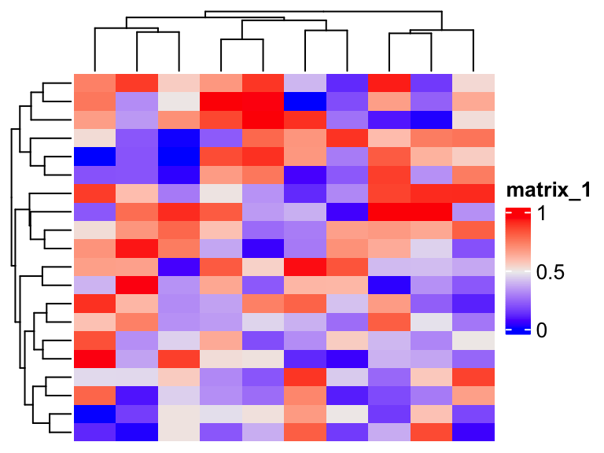

```r
n_rows <- 20
n_cols <- 10
mat <- matrix(
  runif(n_rows * n_cols),
  nrow = n_rows, ncol = n_cols)
Heatmap(mat)
```

We can change the legend’s title using `name`:

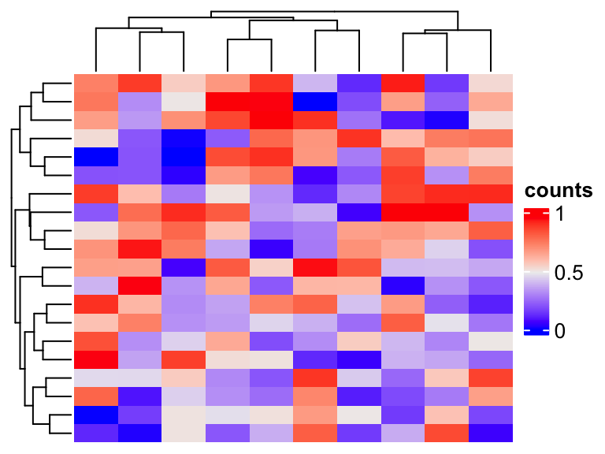

```r
Heatmap(mat, name = "counts")
```

And the color palette (default blue, white, red) using `col`:

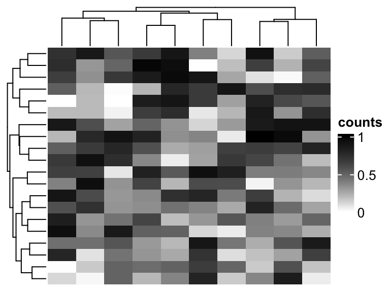

```r
Heatmap(mat,
  name = "counts",
  col = c("white", "black"))
```

Each entry value can be visualized separately as a rectangular grid:

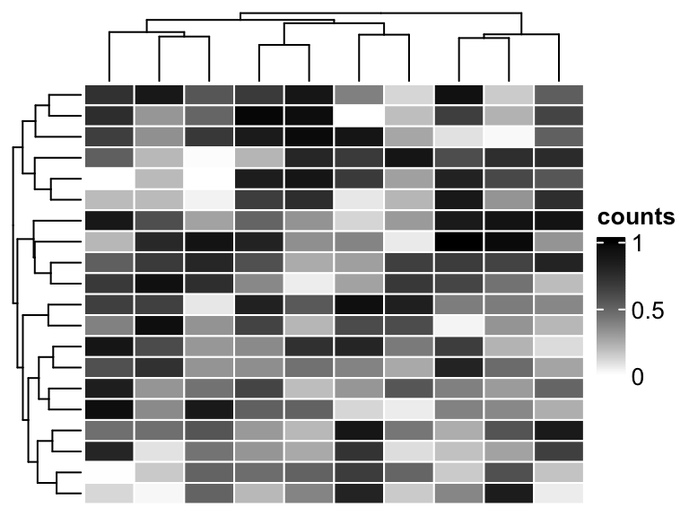

```r
Heatmap(mat,
  name = "counts",
  col = c("white", "black"),
  rect_gp = gpar(col = "white"))
```

Let’s add row and column labels by specifying the row and column names of the matrix:

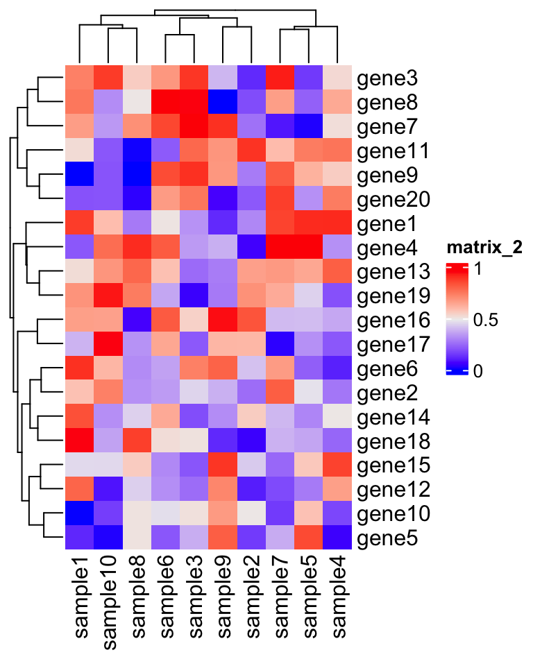

```r
rownames(mat) <- paste0("gene", 1:nrow(mat))
colnames(mat) <- paste0("sample", 1:ncol(mat))
Heatmap(mat)
```

## Clustering & Labels

By default, `Heatmap` will re-order rows and columns according to hierarchical clustering, and add the corresponding dendrograms on the left and top. We can surpress this behavior by setting `cluster_rows/columns = FALSE`:

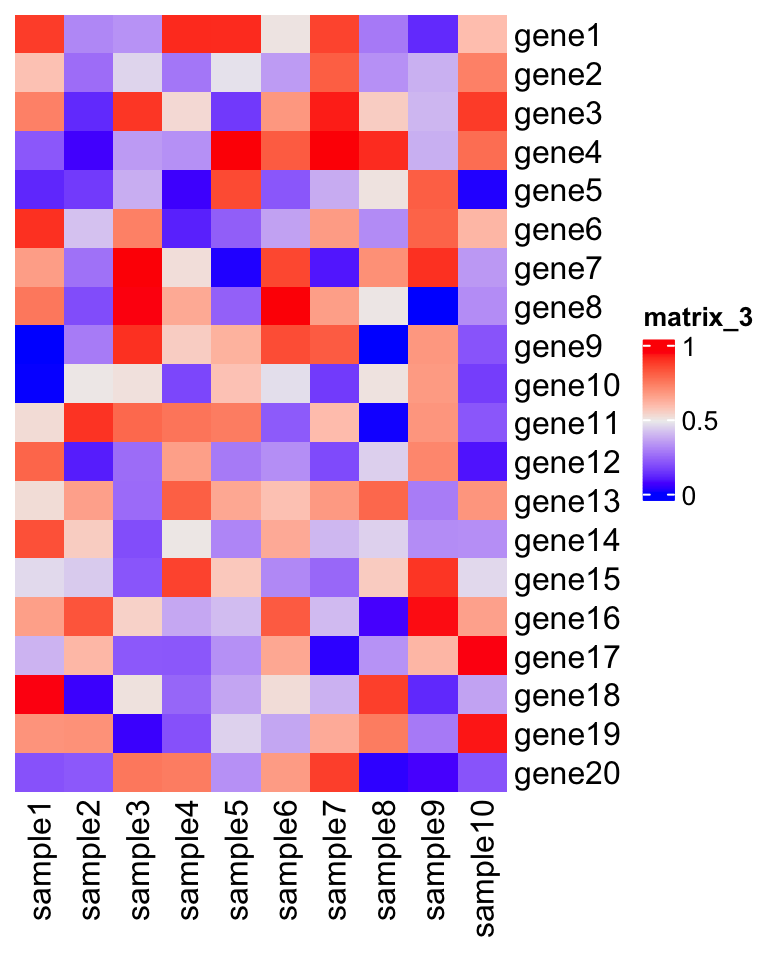

```r
Heatmap(mat,
  cluster_rows = FALSE,
  cluster_columns = FALSE)
```

Let’s move the row labels to the left by setting `row_names_side = "left"`:

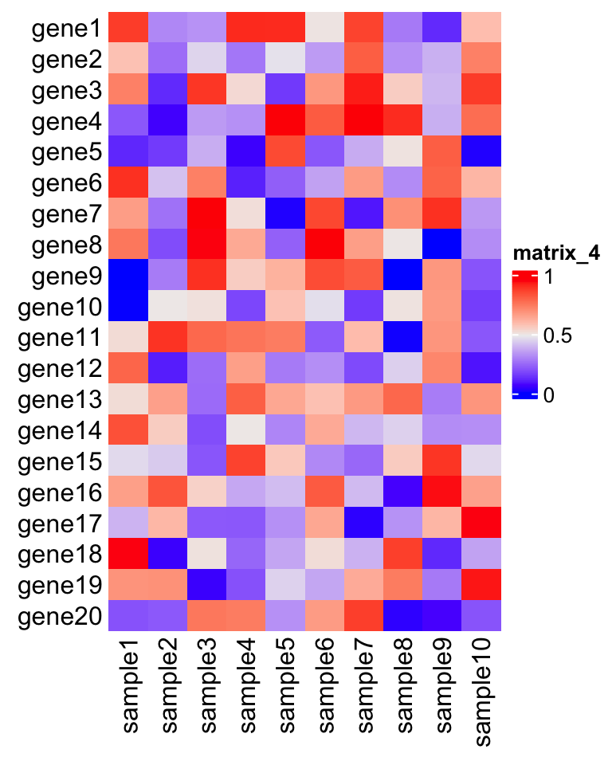

```r
Heatmap(mat,
  cluster_rows = FALSE,
  cluster_columns = FALSE,
  row_names_side = "left")
```

If we prefer to show genes with the same pattern together, we could cluster the rows by setting `cluster_rows = TRUE` (the default):

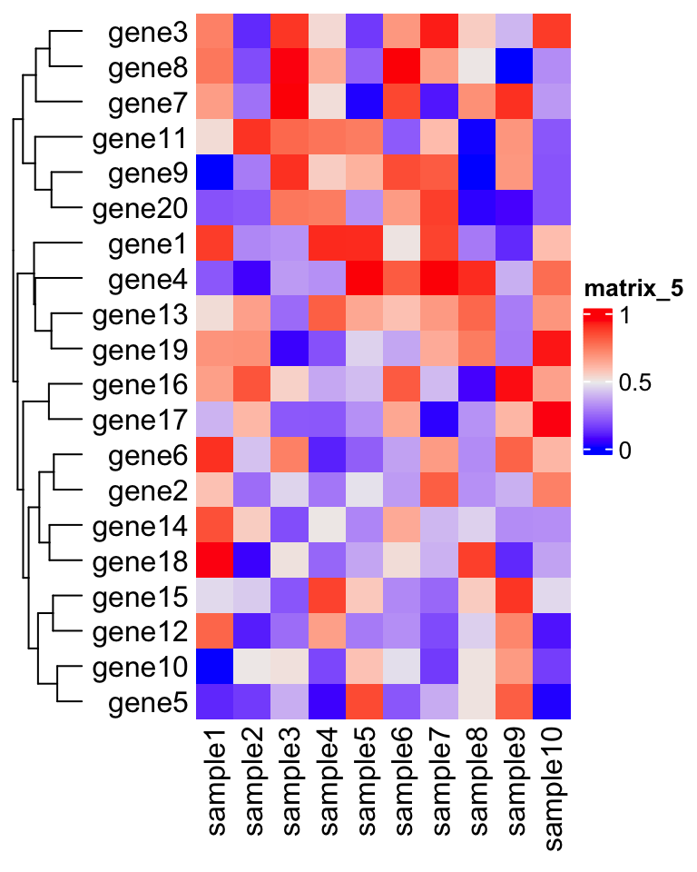

```r
Heatmap(mat,
  cluster_rows = TRUE,
  cluster_columns = FALSE,
  row_names_side = "left")
```

## Annotation

We can label the samples by adding an annotation to the columns of the heatmap:

```r
sampAnno <- rep(c("Control", "Treated"), each = 5)
names(sampAnno) <- colnames(mat)
sampAnno
```

```
##   sample1   sample2   sample3   sample4   sample5   sample6   sample7   sample8
## "Control" "Control" "Control" "Control" "Control" "Treated" "Treated" "Treated"
##   sample9  sample10
## "Treated" "Treated"
```

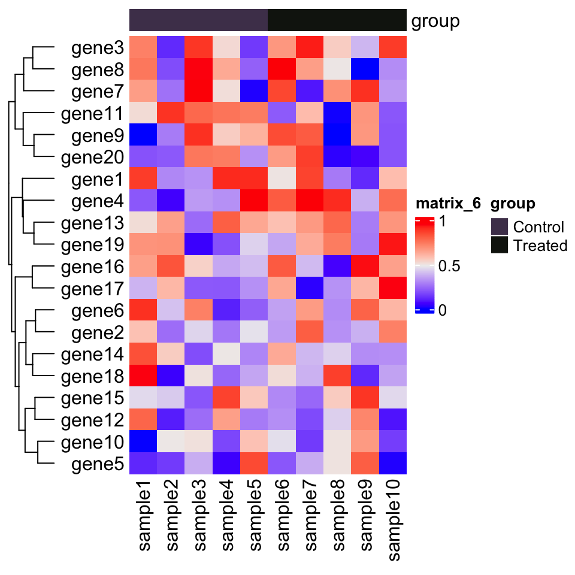

```r
ha1 <- HeatmapAnnotation(group = sampAnno)
Heatmap(mat,
  cluster_rows = TRUE,
  cluster_columns = FALSE,
  row_names_side = "left",
  top_annotation = ha1)
```

The colors for `"Control"` and `"Treated"` samples in the annotation above are random, and will change each time we redraw the heatmap above. We can fix these to a specific pair of colors using `col` in `HeatmapAnnotation`:

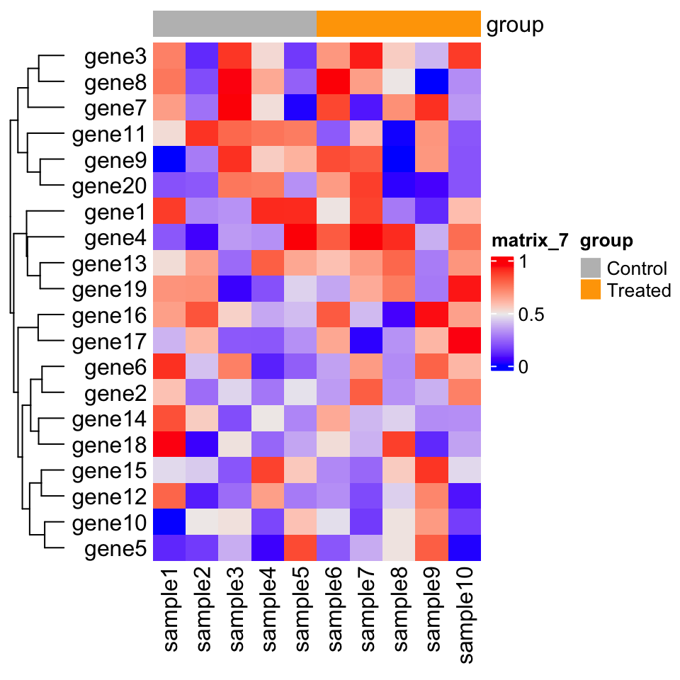

```r
ha2 <- HeatmapAnnotation(
  group = sampAnno,
  col = list(group = c(
    "Treated" = "orange",
    "Control" = "grey")))
Heatmap(mat,
  cluster_rows = TRUE,
  cluster_columns = FALSE,
  row_names_side = "left",
  top_annotation = ha2)
```

A boxplot on the right-hand side of the heatmap can be used to summarize the expression level of each gene across samplese:

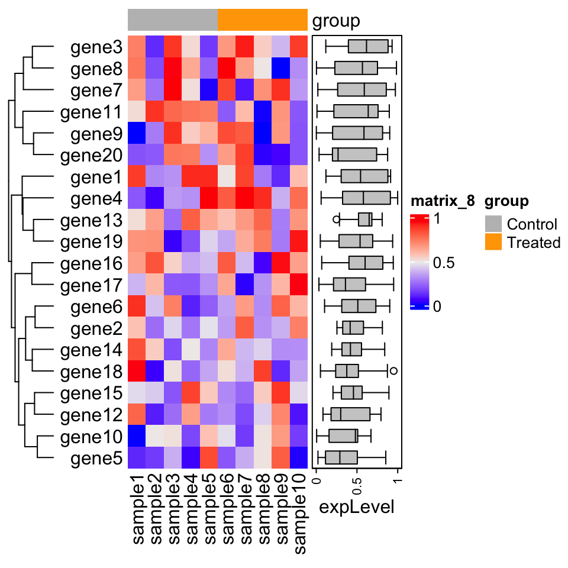

```r
ha3 <- rowAnnotation(expLevel = anno_boxplot(mat))
Heatmap(mat,
  cluster_rows = TRUE,
  cluster_columns = FALSE,
  row_names_side = "left",
  top_annotation = ha2,
  right_annotation = ha3)
```

We might want to compare the expression level of genes between groups. To do this, we draw a scatter plot. The groups are again highlighted in different colors.

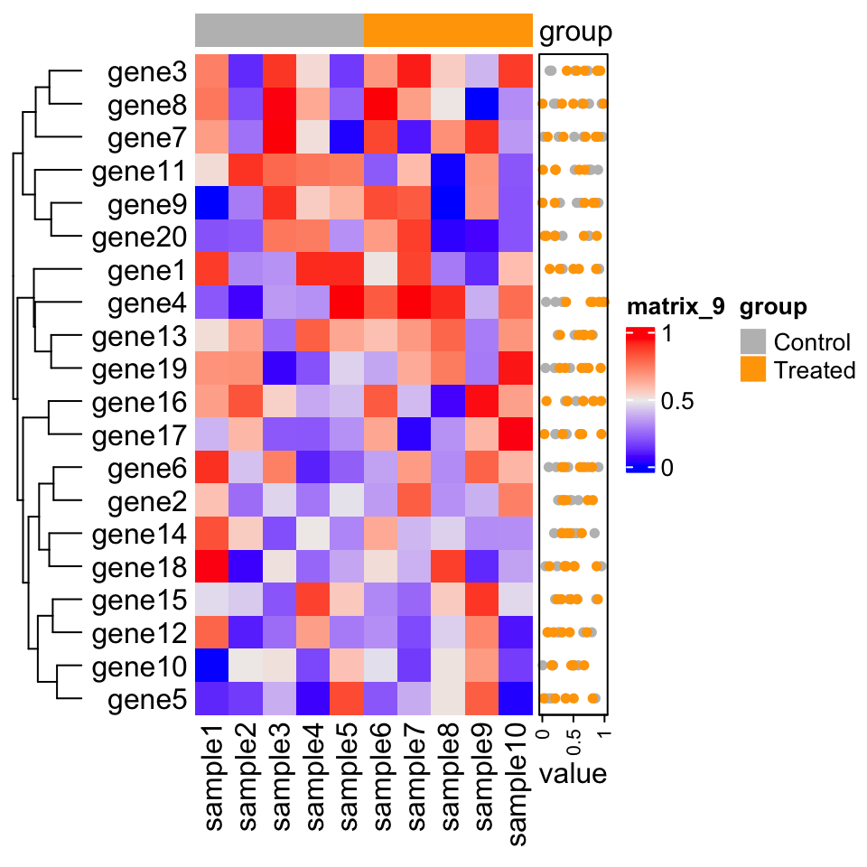

```r
ha4 <- rowAnnotation(value = anno_points(mat,
  gp = gpar(col = rep(c("grey", "orange"), each = 5))))
Heatmap(mat,
  cluster_rows = TRUE,
  cluster_columns = FALSE,
  row_names_side = "left",
  top_annotation = ha2,
  right_annotation = ha4)
```

## Legend & Titles

A legend for the scatter plot created above could be added as follows:

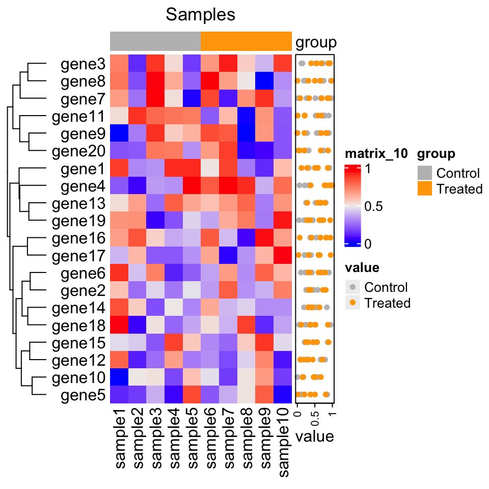

```r
l = Legend(
  title = "value", type = "points",
  labels = c("Control", "Treated"),
  legend_gp = gpar(
    col = c("grey", "orange"),
    fill = c("grey", "orange")))
p <- Heatmap(mat,
  cluster_rows = TRUE,
  cluster_columns = FALSE,
  row_names_side = "left",
  column_title = "Samples",
  top_annotation = ha2,
  right_annotation = ha4)
draw(p, heatmap_legend_list = list(l))
```

## Multiple heatmaps

The `ComplexHeatmap` package allows us to compute multiple `Heatmap`s using `+`:

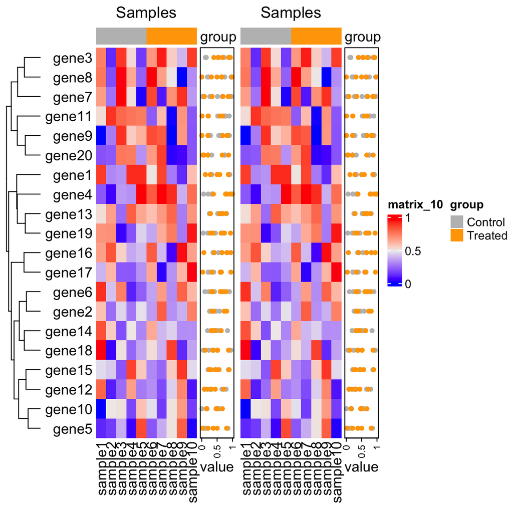

```r
p + p
```